## #Week 5: Dimensionality reduction techniques

```r
library(dplyr)
library(GGally)
```

```r
library(ggplot2)
library(corrplot)
```

I have done my own wrangling, but to ensure compatibility and readability I import the external set.

```r
human <- read.table("http://s3.amazonaws.com/assets.datacamp.com/production/course_2218/datasets/human2.txt",
  sep=",",
  header=TRUE)
```

Next a graphical overview of the dataset and summaries of the variables.

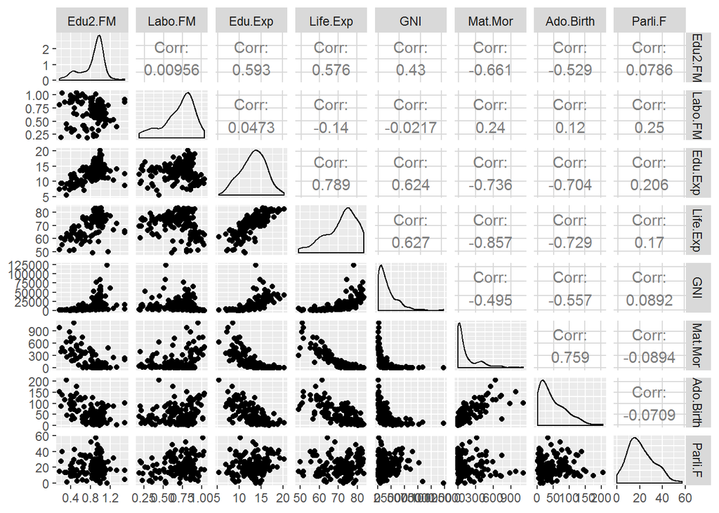

```r
vis <- ggpairs(human[,])
vis
```

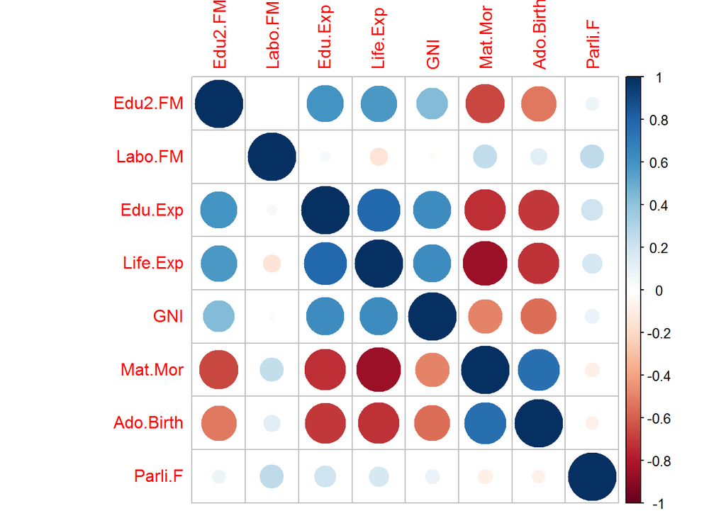

```r
cor(human) %>% corrplot()
```

```r
summary(human)
```

```
##     Edu2.FM          Labo.FM          Edu.Exp         Life.Exp
##  Min.   :0.1717   Min.   :0.1857   Min.   : 5.40   Min.   :49.00
##  1st Qu.:0.7264   1st Qu.:0.5984   1st Qu.:11.25   1st Qu.:66.30
##  Median :0.9375   Median :0.7535   Median :13.50   Median :74.20
##  Mean   :0.8529   Mean   :0.7074   Mean   :13.18   Mean   :71.65
##  3rd Qu.:0.9968   3rd Qu.:0.8535   3rd Qu.:15.20   3rd Qu.:77.25
##  Max.   :1.4967   Max.   :1.0380   Max.   :20.20   Max.   :83.50
##       GNI            Mat.Mor         Ado.Birth         Parli.F
##  Min.   :   581   Min.   :   1.0   Min.   :  0.60   Min.   : 0.00
##  1st Qu.:  4198   1st Qu.:  11.5   1st Qu.: 12.65   1st Qu.:12.40
##  Median : 12040   Median :  49.0   Median : 33.60   Median :19.30
##  Mean   : 17628   Mean   : 149.1   Mean   : 47.16   Mean   :20.91
##  3rd Qu.: 24512   3rd Qu.: 190.0   3rd Qu.: 71.95   3rd Qu.:27.95
##  Max.   :123124   Max.   :1100.0   Max.   :204.80   Max.   :57.50
```

In the colourful correlation plot we can see the relationships between the variables. Quite expected relations here, to be frank.

Maternal mortality and life expectancy have a quite strong negative correlation (larger red ball), ergo the higher the maternal mortality the lower the life expectancy in said country.

A positive correlation for maternal mortality is on the other hand adolescent births. That is, the occurrence of maternal mortality and teenage pregnancies tend to go hand in hand.

On a more positive note, a positive correlation between expected years of schooling and life expectancy is found in the plot. On the other hand, this doesn’t by any means show any causality. One could imagine that a person has more time to study simply because the person lives longer.

Something that shows a bit more promise for education are the pairs between expected education and maternal mortality and adolescent births. These pairs both correlate negatively. So there are clues of the societal and public health benefits of education, but again correlation doesn’t equal causation.

Next: perform a principal component analysis (PCA) on the dataset.

```r
pca_human <- prcomp(human)

summary(pca_human)
```

```
## Importance of components:
##                              PC1      PC2   PC3   PC4   PC5   PC6    PC7
## Standard deviation     1.854e+04 185.5219 25.19 11.45 3.766 1.566 0.1912
## Proportion of Variance 9.999e-01   0.0001  0.00  0.00 0.000 0.000 0.0000
## Cumulative Proportion  9.999e-01   1.0000  1.00  1.00 1.000 1.000 1.0000
##                           PC8
## Standard deviation     0.1591
## Proportion of Variance 0.0000
## Cumulative Proportion  1.0000
```

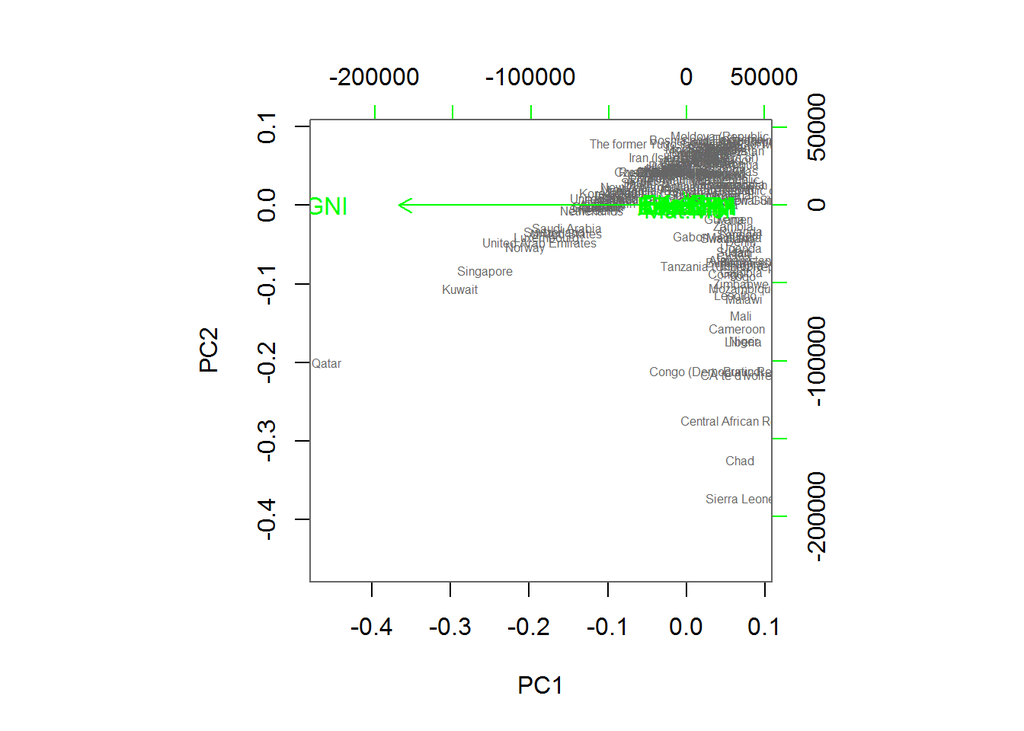

```r
biplot(pca_human, choices = 1:2, cex=c(0.5,1), col=c("grey40","green"))
```

As noted with regard to the distribution within the variables earlier, the differences are quite large between different countries. Therefore, when handling a holistic and global comparison like this one, the variability is all over the place. This is seen both in the summary above, where the figures are astronomical and in the biplot which doesn’t help at all in explaining this data. Analytically PCA might also assume that variables with larger variance are more important than dito with smaller variance, so therefore a PCA with unscaled data will probably be a poor one.

Because of these problems, we next standardize the data so that all observations become comparable with each other.

```r
human_std <- scale(human)

pca_human2 <- prcomp(human_std)

s <- summary(pca_human2)
s
```

```
## Importance of components:
##                           PC1    PC2     PC3     PC4     PC5     PC6
## Standard deviation     2.0708 1.1397 0.87505 0.77886 0.66196 0.53631
## Proportion of Variance 0.5361 0.1624 0.09571 0.07583 0.05477 0.03595
## Cumulative Proportion  0.5361 0.6984 0.79413 0.86996 0.92473 0.96069
##                            PC7     PC8
## Standard deviation     0.45900 0.32224
## Proportion of Variance 0.02634 0.01298
## Cumulative Proportion  0.98702 1.00000
```

```r
pca_pr <- round(1*s$importance[2, ], digits = 3)
pca_pr <- (pca_pr*100)
pca_pr
```

```
##  PC1  PC2  PC3  PC4  PC5  PC6  PC7  PC8
## 53.6 16.2  9.6  7.6  5.5  3.6  2.6  1.3
```

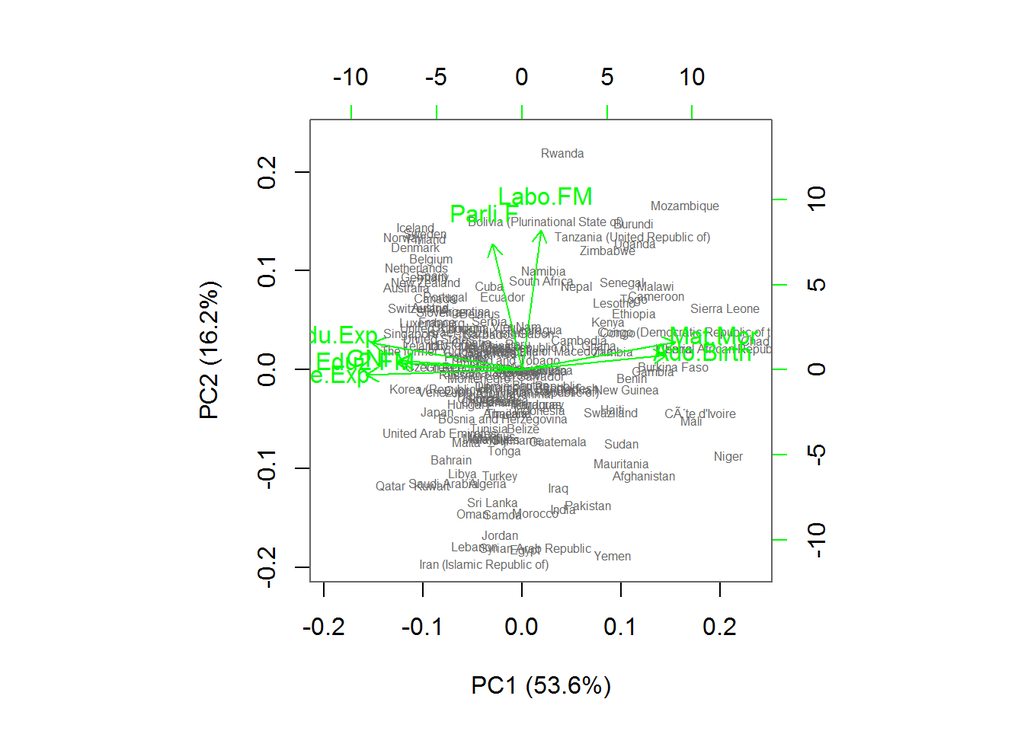

```r
pca_lab <- paste0(names(pca_pr), " (", pca_pr, "%)")

biplot(pca_human2, choices = 1:2, cex=c(0.5,1), col=c("grey40","green"), xlab = pca_lab[1], ylab = pca_lab[2])
```

I write my descriptions of the results here instead of in captions in the plot. Too much to say, wouldn’t fit in a caption.

Now we have much clearer results than in the previous plot, and we can see clear groupings of correlations basically possible to divide into three groups: 1. Wealth and quality of life, 2. Female empowerment and 3. Reproductive issues.

When reading a biplot, the smaller the angle between specific arrows are the larger the correlation between their corresponding variables are. So in group 1, we see that wealth (GNI), life expectancy, expected education and education among females all correlate quite well with each other. In group 2, countries with a larger share of female members of parliament also tend to have a larger female participation rate in the work force. And in group 3, as stated earlier, here again it is shown that maternal mortality and adolescent births often go hand in hand. Naturally, with these three groups having large angles between each other, they do not correlate that much with each other.

Moving on to the arrows and their relations to the PC1- and PC2-axis. Group 1 is negatively correlated with PC1 and mostly not correlated at all with PC2. Group 2 is positively correlated with PC2 and mostly not correlated at all with PC1. And group 3 is positively correlated with PC1 but mostly not correlated at all with PC2.

Something worth mentioning that doesn’t speak in favor of this analysis is its lack of variability coverage. The PC1 and PC2 together cover less than 70 percent of the variability (visible both in the axis and in the summary above: “cumulative proportion”). That means less than 70 percent of the variability in the data here can be explained with this analysis. Might be though that that is a fairly okay coverage, considering the massive variation in the data and multitude of outliers.

Moving on to MCA and the tea dataset. First we load the dataset and explore the structure and dimensions.

```r
library(FactoMineR)
library(dplyr)
library(ggplot2)
library(tidyr)

tea <- read.table("http://factominer.free.fr/course/donnees/data_MCA_Tea.csv",
                  sep=";",
                  header=TRUE)
dim(tea)
```

```
## [1] 300  36
```

```r
str(tea)
```

```
## 'data.frame':    300 obs. of  36 variables:
##  $ breakfast       : Factor w/ 2 levels "breakfast","Not.breakfast": 1 1 2 2 1 2 1 2 1 1 ...
##  $ tea.time        : Factor w/ 2 levels "Not.tea time",..: 1 1 2 1 1 1 2 2 2 1 ...
##  $ evening         : Factor w/ 2 levels "evening","Not.evening": 2 2 1 2 1 2 2 1 2 1 ...
##  $ lunch           : Factor w/ 2 levels "lunch","Not.lunch": 2 2 2 2 2 2 2 2 2 2 ...
##  $ dinner          : Factor w/ 2 levels "dinner","Not.dinner": 2 2 1 1 2 1 2 2 2 2 ...
##  $ always          : Factor w/ 2 levels "always","Not.always": 2 2 2 2 1 2 2 2 2 2 ...
##  $ home            : Factor w/ 2 levels "home","Not.home": 1 1 1 1 1 1 1 1 1 1 ...
##  $ work            : Factor w/ 2 levels "Not.work","work": 1 1 2 1 1 1 1 1 1 1 ...
##  $ tearoom         : Factor w/ 2 levels "Not.tearoom",..: 1 1 1 1 1 1 1 1 1 2 ...
##  $ friends         : Factor w/ 2 levels "friends","Not.friends": 2 2 1 2 2 2 1 2 2 2 ...
##  $ resto           : Factor w/ 2 levels "Not.resto","resto": 1 1 2 1 1 1 1 1 1 1 ...
##  $ pub             : Factor w/ 2 levels "Not.pub","pub": 1 1 1 1 1 1 1 1 1 1 ...
##  $ Tea             : Factor w/ 3 levels "black","Earl Grey",..: 1 1 2 2 2 2 2 1 2 1 ...
##  $ How             : Factor w/ 4 levels "alone","lemon",..: 1 3 1 1 1 1 1 3 3 1 ...
```

[output cut: 22 more lines]

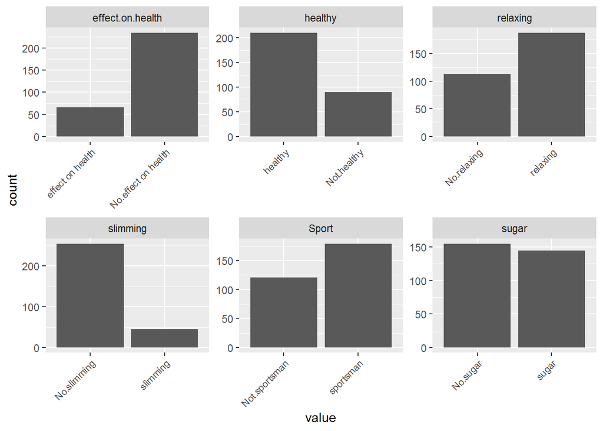

```r
keep_columns <- c("Sport", "slimming", "relaxing", "healthy", "sugar", "effect.on.health")

tea_time <- select(tea, one_of(keep_columns))

gather(tea_time) %>% ggplot(aes(value)) + facet_wrap("key", scales = "free") + geom_bar() + theme(axis.text.x = element_text(angle = 45, hjust = 1, size = 8))
```

The tea dataset is a questionnaire with 36 questions regarding tea consumption. 300 individuals have participated in the questionnaire. The dimensions are way too big to visualize neatly and understandibly in one plot. Above instead a smaller sample.

Next we move on to MCA. We’ll utilize the same columns as plotted above.

```r
mca <- MCA(tea_time, graph = FALSE)
summary(mca)
```

```
##
## Call:
## MCA(X = tea_time, graph = FALSE)
##
##
## Eigenvalues
##                        Dim.1   Dim.2   Dim.3   Dim.4   Dim.5   Dim.6
## Variance               0.231   0.196   0.176   0.162   0.139   0.098
## % of var.             23.073  19.550  17.558  16.158  13.856   9.804
## Cumulative % of var.  23.073  42.624  60.182  76.340  90.196 100.000
##
## Individuals (the 10 first)
##                  Dim.1    ctr   cos2    Dim.2    ctr   cos2    Dim.3
## 1             | -0.081  0.009  0.009 | -0.218  0.081  0.067 | -0.264
## 2             | -0.129  0.024  0.024 |  0.265  0.120  0.102 | -0.400
## 3             | -0.405  0.237  0.318 | -0.117  0.023  0.026 | -0.056
## 4             | -0.365  0.192  0.198 | -0.254  0.110  0.096 | -0.166
## 5             |  0.209  0.063  0.052 | -0.284  0.138  0.097 | -0.061
## 6             | -0.405  0.237  0.318 | -0.117  0.023  0.026 | -0.056
## 7             | -0.405  0.237  0.318 | -0.117  0.023  0.026 | -0.056
## 8             | -0.405  0.237  0.318 | -0.117  0.023  0.026 | -0.056
## 9             |  0.209  0.063  0.052 | -0.284  0.138  0.097 | -0.061
## 10            | -0.414  0.247  0.263 |  0.230  0.090  0.081 | -0.302
##                  ctr   cos2
## 1              0.133  0.098 |
## 2              0.304  0.232 |
## 3              0.006  0.006 |
## 4              0.052  0.041 |
## 5              0.007  0.004 |
## 6              0.006  0.006 |
## 7              0.006  0.006 |
## 8              0.006  0.006 |
## 9              0.007  0.004 |
## 10             0.173  0.140 |
##
## Categories (the 10 first)
##                   Dim.1     ctr    cos2  v.test     Dim.2     ctr    cos2
## Not.sportsman |  -0.014   0.006   0.000  -0.201 |   0.548  10.337   0.203
## sportsman     |   0.010   0.004   0.000   0.201 |  -0.371   6.988   0.203
## No.slimming   |   0.101   0.632   0.058   4.175 |  -0.204   3.021   0.236
```

[output cut: 12 more lines]

```
## No.relaxing     8.494 |  -0.539  10.398   0.176  -7.249 |
## relaxing       -8.494 |   0.326   6.283   0.176   7.249 |
## healthy         3.521 |   0.003   0.001   0.000   0.087 |
## Not.healthy    -3.521 |  -0.008   0.002   0.000  -0.087 |
## No.sugar       11.083 |  -0.165   1.343   0.029  -2.958 |
## sugar         -11.083 |   0.177   1.435   0.029   2.958 |
##
## Categorical variables (eta2)
##                    Dim.1 Dim.2 Dim.3
## Sport            | 0.000 0.203 0.092 |
## slimming         | 0.058 0.236 0.546 |
## relaxing         | 0.149 0.241 0.176 |
## healthy          | 0.659 0.041 0.000 |
## sugar            | 0.005 0.411 0.029 |
## effect.on.health | 0.514 0.040 0.210 |
```

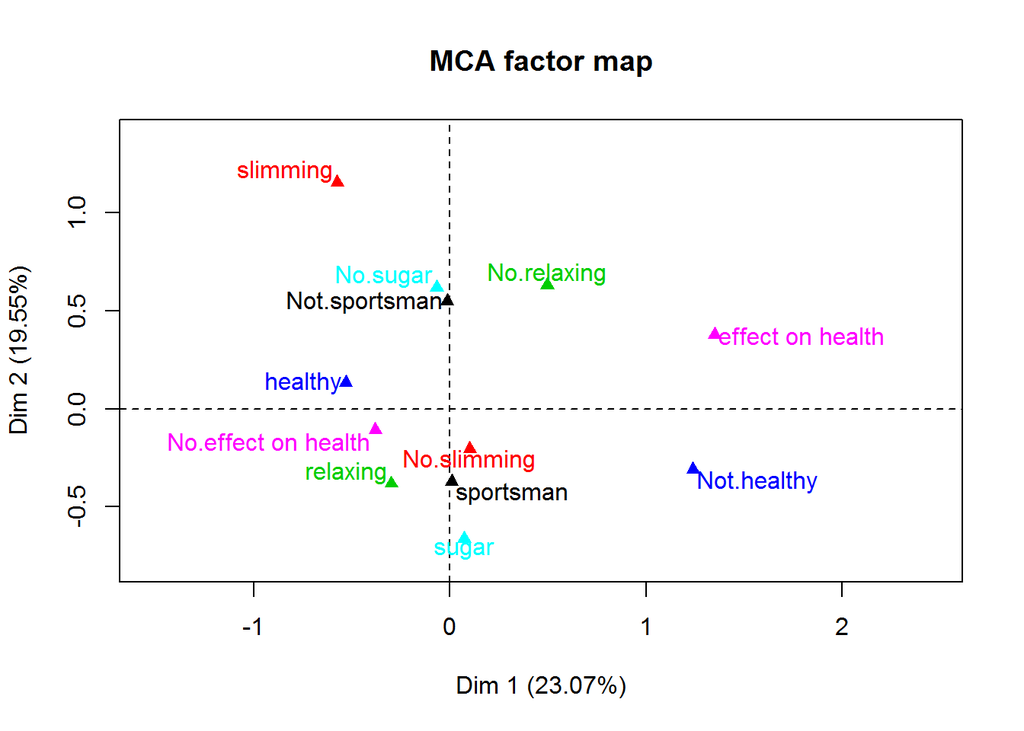

```r
plot(mca, invisible=c("ind"), habillage="quali")
```

Great shit.